# Ciencia de Datos para Economistas

Clase 1

Autores/as

Afiliación

Fecha de publicación

17 de marzo de 2025

# ¡Hola Mundo! (Hello world!)

## Equipo de Enseñanza

| Profesor |
| --- |
| José Miguel Avendaño I. |
| Juan Pablo Goncalves L. |
| Jesús Sánchez |

[output not shown]

## Participantes Curso

- Expectativas?
- Previo:
  - ¿Programación?
  - ¿Investigaciones?
  - ¿Trabajan en el área?

`15:00`

## Ciencia de Datos, por ejemplo

Extraer conocimiento desde un conjunto de datos

## Excel - no …

[figure not shown]

## ¡por qué R?

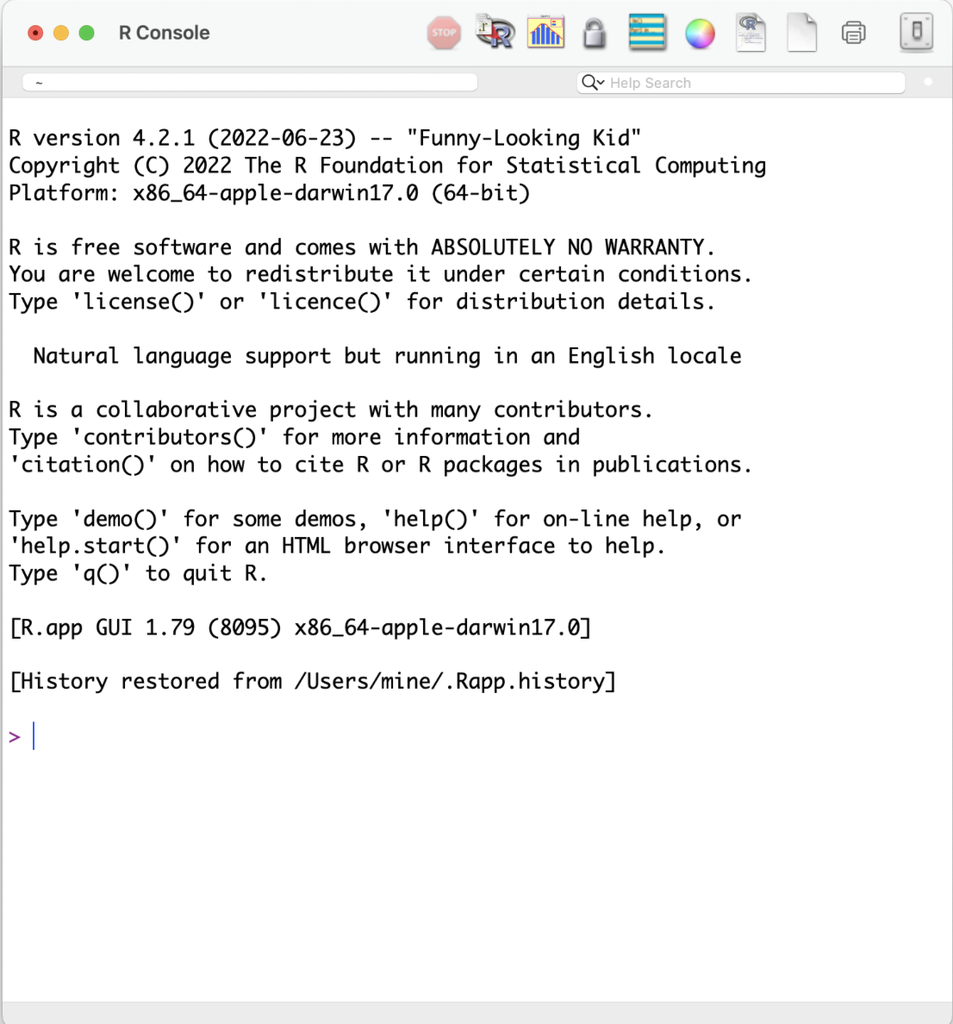

## RStudio

[figure not shown]

## Objetivos del Curso

- **Dominar métodos de programación en R**: Los estudiantes aprenderán a utilizar R como herramienta para analizar y procesar datos económicos, permitiéndoles validar hipótesis y sustentar investigaciones.
- **Desarrollar capacidades analíticas**: Se hará énfasis en la interpretación de resultados obtenidos al procesar datos, fomentando el pensamiento crítico y la toma de decisiones informadas.
- **Aplicar conceptos de ciencia de datos y ciencias sociales computacionales**: Los estudiantes se familiarizarán con estos campos interdisciplinarios, aprendiendo a extraer conocimiento y modelar fenómenos sociales y económicos.
- **Manejar grandes conjuntos de datos**: Los estudiantes aprenderán a utilizar R para manejar eficientemente grandes volúmenes de datos, una habilidad crucial en el campo de la economía.

## Objetivos del Curso- cont.

- **Crear visualizaciones de datos efectivas**: Los estudiantes aprenderán a utilizar R para generar gráficos y visualizaciones claras e interactivas, facilitando la comunicación de resultados de investigación.
- **Garantizar la reproducibilidad de investigaciones**: Los estudiantes aprenderán a documentar y reproducir sus análisis en R, aumentando la transparencia y credibilidad de sus investigaciones.
- **Comunicar resultados de investigación de manera efectiva**: Los estudiantes aprenderán a utilizar R para generar reportes, gráficos, tablas y otros productos que faciliten la comunicación de sus hallazgos.
- **Familiarizarse con el uso de herramientas de acceso a datos**: Los estudiantes aprenderán a utilizar API’s y diferentes recursos de internet para la obtención de datos, y a crear conjuntos de datos de libre acceso.

## Objetivos del Curso - cont.

- **Comprender y aplicar el ciclo de vida de la ciencia de datos**: Los estudiantes adquirirán conocimiento sobre las diferentes etapas del ciclo de ciencia de datos, desde la obtención y limpieza de datos hasta el modelado, análisis y visualización, permitiéndoles abordar proyectos de investigación de manera integral.

# Ciclo de la Ciencia de Datos

## Vista Integral

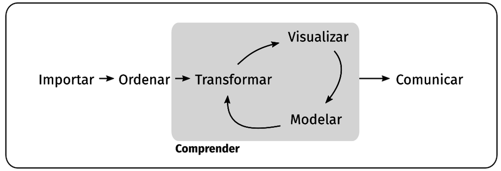

## Importar

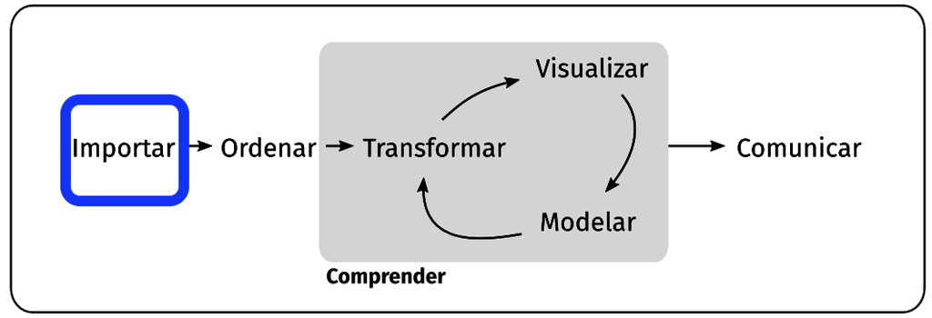

## Ordenar + transformar

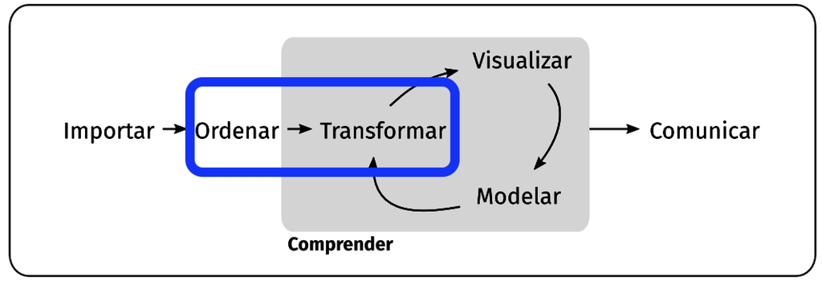

## Visualizar

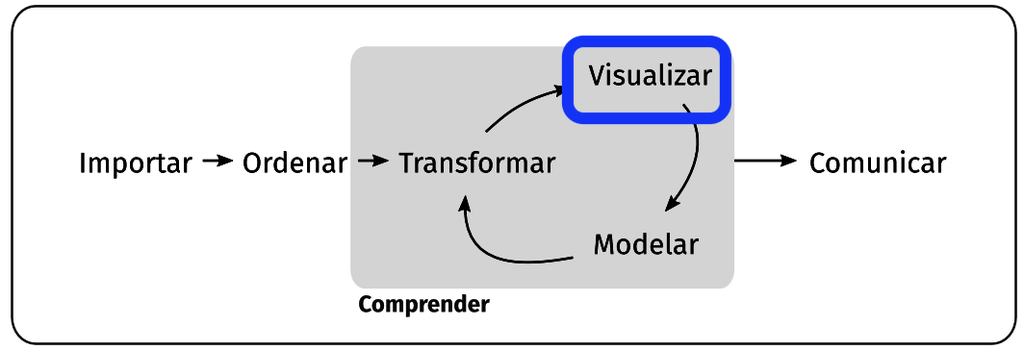

## Modelar

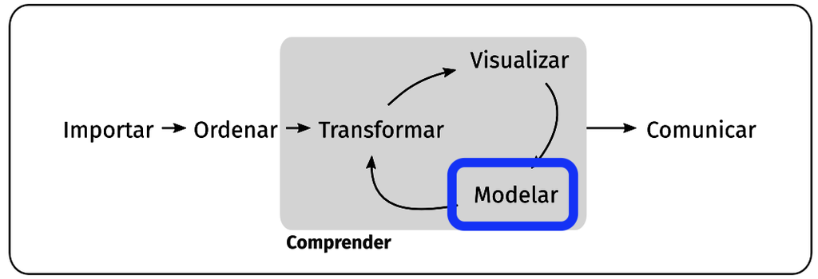

Las clases de modelado estarán a cargo del Prof. Juan Pablo Goncalves.

## Comprender

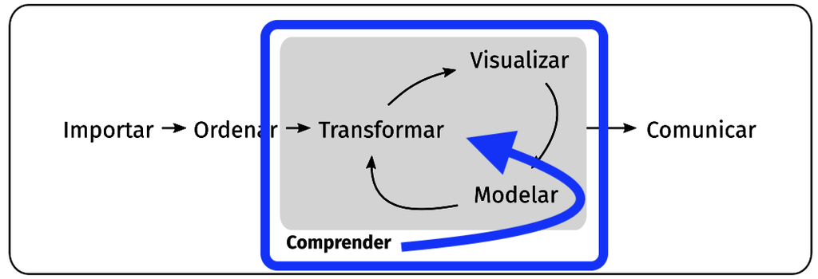

## Comunicar

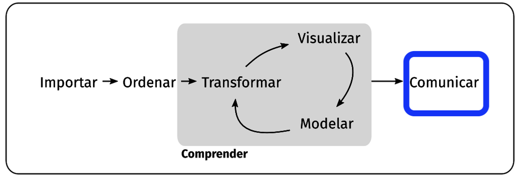

## Generar Conjunto de Datos

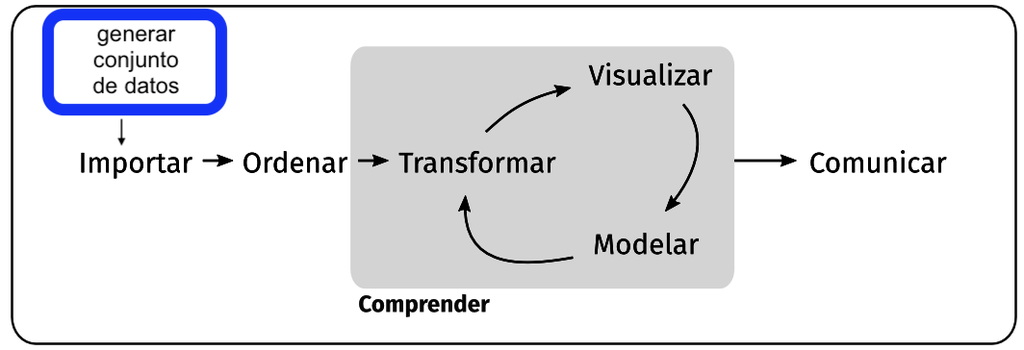

## Programar

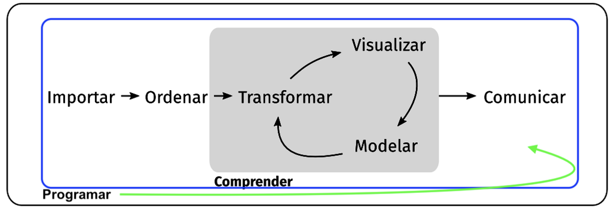

## ¿Para Qué?

- Estudiante debe pensar como un Científico de Datos:
  - Investigador
  - Crítico
  - Innovador

## Promesa

- Nociones de programación
- Obtener y crear conjunto de datos
- Presentar investigaciones

# Componentes del Curso

## Página Web

https://ucveconomia-r4ds-2025-1.netlify.app

[figure not shown]

- Todos los materiales
- Enlaces a recursos

## Salón

- Laboratorio piso 2

## Clases

- Presenciales
- Remotas de complemento
- Remotas opcionales
- Asistencia obligatoria
- Un poco de:
  - Clase tradicional
  - Codificación + demos
  - Ejercicios, talleres, soluciones

## Laboratorios

- 10 planificados (30 minutos duración)
- Cada 3 clases
- Oportunidad para trabajar en tareas del curso con soporte
- Oportunidad de trabajar con miembros del equipo del proyecto
- Se pueden extender por 45 minutos una vez finalizada la clase

# Herramientas del Curso

- Uso Discord: comunicación, recomendaciones, soporte
- Repositorio GitHub: optimizar flujos de trabajo
- Página web del curso
- RStudio Cloud-Server: computación en la nube
- Material bibliográfico

## Discord- vínculo

[figure not shown]

## Discord

- Foro en línea para plantear y responder preguntas
- Deberá unirse al servidor del curso para tener acceso.
- Haga y responda aquí a preguntas relacionadas con la logística del curso, las tareas, etc.
- Preguntas personales (por ejemplo, extensiones, enfermedades, etc.) deben ser a través de correo electrónico.
- Una vez que te unas, navega por los canales para asegurarte de que estás publicando preguntas en el canal correcto, actualiza tu perfil con tu nombre, foto/avatar tuyo que coincida con tu perfil de GitHub.

## Repositorio GitHub

- láminas y códigos disponibles en https://github.com/javendaXgh/ucveconomiar4ds-2025-1
- Se espera que a lo largo del curso se enseñen distintas bondades sobre esta herramienta.

## Página Web del Curso

- En https://ucveconomiar4ds.netlify.app se encuentra el acceso al sitio de la versión actual del curso y de la edición anterior.
- En la página estarán publicadas los talleres, las láminas de las clases, pautas generales, el código de conducta del estudiante, etc.

## RStudio Cloud-Server

El IDE (entorno de desarrollo) que se usará es RStudio y existe una versión en la nube que es una alternativa en caso de contar con una computadora no apta para correr los códigos o instalar los paquetes necesarios.

## Material Bibliográfico

- r4ds en español
- Hands-On Programming with R
- Ciencia de Datos para Gente Sociable
- Muchos otros

Revisar /recursos.html

## Soporte Curso

- En la página del curso se publicarán las horas de atención
- Realizar preguntas en el canal foro en el Discord
- Evitar uso de correo para soporte
- Revisar distintos canales en Discord, p. ejem: *errores-de-códigos*

## Anuncios del Curso

- Se publicarán en el canal *anuncios-clases* del Discord u otro medio digital
- Revisar los canales de comunicación al menos el día anterior a cada una de las clases

## Inclusión

Mi objetivo es que este curso sea inclusivo y beneficioso para estudiantes de todos los orígenes y perspectivas. Me comprometo a atender las necesidades de aprendizaje tanto dentro como fuera del aula, y a valorar la diversidad que cada estudiante aporta como un recurso, una fortaleza y una ventaja.

Si sientes que tu rendimiento en la clase se ve afectado por experiencias externas, no dudes en hablar conmigo. Quiero ser un apoyo para ti. Si prefieres hablar con alguien fuera del curso, la Escuela de Economía cuenta con un departamento a cargo del Prof. Jesús Sanchez que puede resultar de gran ayuda.

Yo, al igual que muchas personas, sigo aprendiendo sobre diversas perspectivas. Si algo dicho en clase (por cualquiera) te hizo sentir incómodo, por favor, háblame al respecto.

# Evaluaciones

## Plan de Evaluación

| Detalle | Porcentaje |
| --- | --- |
| 8 a 10 Tareas | 20 % |
| Ciclo C.D. sobre un conjunto de datos | 20 % |
| Examen parcial mitad del curso | 20 % |
| Asistencia | 5 % |
| Intervenciones | 5% |
| Proyecto Final | 30 % |

## Tareas (20%)

- Se tiene pautado un total de (8 a 10) tareas que según el desarrollo del curso puede verse disminuida la cantidad.
- Se asignarán aproximadamente cada 3 clases.
- Se tiene pautado que tenga un peso de 20% de la nota.
- La recomendación es hacer las tareas con tiempo para que el profesor pueda responder oportunamente cualquier consulta.
- Se elimina la tarea que tenga la más baja nota al momento de promediar las notas obtenidas.
- Deben ser entregadas para la fecha asignada, penalidad por retardo
- Máximo 7 días de retardo, sin entregas posteriores.

## Trabajo - Ciclo C.D. sobre un conjunto de datos (20%)

- Se entregará un conjunto de datos al estudiante para que sobre él realice distintas fases de lo que constituye un ciclo de Ciencia de Datos.
- La entrega será mediante un script o un reporte elaborado en quarto.
- Tendrá un peso de 20%.
- Fecha estimada para entrega de los requerimientos, el 29-04-2025
- Fecha de entrega del producto final, el 28-05-25

## Examen parcial mitad del curso (20%)

- Un poco después de la mitad del curso se realizará un examen parcial para que sean evaluados los distintos conocimientos impartidos en el curso.
- Este examen será escrito, no en la computadora.
- Tendrá una duración máxima de 60 minutos.
- El peso que tendrá el examen es del 20%.
- Fecha pautada para el examen, el 14-05-2025.

**Precaución**

Las fechas del examen no se puede cambiar y no se harán exámenes de recuperación. Si usted no puede asistir al examen en la fecha indicada, debería evaluar abandonar este curso.

## Asistencia (5%)

- La asistencia al curso es obligatoria y se recomienda hacer lo posible por atender a todas las clases, ya que todos los temas impartidos están relacionados y son incrementales.
- Si ocurre alguna falta, se pide al estudiante no pedir asistencia en la siguiente clase al compañero de estudio una vez que inicie la clase ya que obstaculizará el aprendizaje.
- El peso otorgado a la asistencia es 5%.

**Tip**

Si asistes a un 85% de las clases, obtendrás todos los puntos de este componente.

**Precaución**

Recuerde tener presente la fecha límite **(25/04/2025)** para retiro de materia si presenta un alto índice de inasistencias

## Intervenciones (5%)

- Las intervenciones y una actitud proactiva, son muy bien valoradas ya que ayudan a facilitar asimilar los contenidos que son impartidos.
- Se asigna un peso de 5% para este componente.

## Proyecto Final (30%)

- Se trabajará durante una parte del curso en realizar un proyecto de ciencia de datos donde se unifiquen distintas fuentes de datos asociadas a la economía venezolana.
- Es uno de los componentes más importantes del curso, ya que se pondrán en práctica los distintos temas abordados.
- Tendrá un peso de 30%.
- Fecha de suministro de los requerimientos del Proyecto Final, el 21-05-25
- Fecha de entrega del Proyecto Final, el 03-07-2025
- Fecha de presentación del Proyecto Final, el 09-07-2025

**Precaución**

Las fechas de presentación del proyecto no se puede cambiar. Si usted no puede asistir ese día, debería evaluar abandonar este curso.

## Proyecto cont.

- Evaluación Equipo de Profesores:
  - calidad código,
  - originalidad,
  - aporte,
  - cumplir con C.C.D
- Elección del conjunto de datos de su preferencia
- Trabajo en equipo 4 a 5 personas
- Presentación final del Proyecto en laboratorio (20 minutos)
- Creación de un póster (afiche) para comunicar (⛔️ bachillerato)
- Se publicará en la página el proyecto
- - info en Leer /proyecto.html

## Trabajo En Equipo

- Trabajo en equipo Proyecto Final (obligatorio)
- Ejercicios en clase (recomendado)
- Expectativas y funciones:
  - Se espera que todos contribuyan con el mismo esfuerzo
  - Se espera que todos entiendan el código entregado

## Política de retardos

### Tareas:

Fuera de plazo, pero hasta una semana después de la fecha indicada:

- 20% tope de penalidad (3% por día de retardo).
- Más tarde: No se concederá nota y no se proporcionarán comentarios por escrito.
- Tenga en cuenta que la puntuación más baja será eliminada, incluso si es un 0.

### Proyecto Ciclo C.D. sobre un conjunto de datos:

Fuera de plazo, pero dentro de dos semanas posterior a la fecha límite:

- 30% tope de penalidad (2% por día de retardo).
- Más tarde: No se concederán créditos y no se proporcionarán comentarios por escrito.

## Política de retardos - cont.

### Proyecto Final

- Debe ser entregado en la fecha indicada y no existe ningún plazo
- Debe ser presentado en la fecha indicada y no existe ningún plazo

## Política de colaboración

- Sólo el trabajo que está claramente asignado como trabajo en equipo debe ser completado en colaboración (proyecto)
- El examen deben ser completado individualmente, no se puede discutir las respuestas con los compañeros de clase, las preguntas de aclaración sólo se debe pedir al profesor
- Las tareas deben completarse individualmente.
- Los laboratorios pueden realizarse en equipos de máximo dos personas.
- No se pueden compartir directamente las respuestas / código con los demás, sin embargo, son bienvenidos a discutir los problemas en general y pedir consejo.

## Compartir y Reusar Código

- Somos conscientes de que existe un enorme volumen de código disponible en la web, al igual de que muchas tareas pueden tener soluciones publicadas.
- A menos que se indique explícitamente lo contrario, la política de este curso es que usted puede hacer uso de cualquier recurso en línea (por ejemplo, StackOverflow o un modelo de lenguaje), pero debe citar explícitamente dónde obtuvo cualquier código que utilice directamente o como inspiración en su(s) solución(es).
- Cualquier código reciclado que se descubra y no se cite explícitamente será tratado como plagio, independientemente de la fuente.

## Herramientas de IA Generativas

Debe tratar la IA generativa, como ChatGPT, igual que a otros recursos que estén disponibles en línea. [^1]

Hay dos principios rectores que rigen el uso de la IA en este curso:

(1) Dimensión cognitiva: Trabajar con IA no debe reducir tu capacidad de pensar con claridad. Practicaremos el uso de la IA para facilitar -en lugar de dificultar- el aprendizaje.

(2) Dimensión ética: Los estudiantes que utilicen IA deben ser transparentes sobre su uso y asegurarse de que se alinea con la integridad académica.

## Herramientas de IA Generativas

- ✅ Herramientas de IA para el código: Puede hacer uso de la tecnología para ejemplos de codificación en las tareas; si lo hace, debe citar explícitamente dónde obtuvo el código. Cualquier código reciclado que se descubra y no se cite explícitamente se tratará como plagio. El uso de la IA debe estar relacionado con los métodos y funciones impartidos en clase.
- ❌ Herramientas de IA para narrativa: A menos que se le indique lo contrario, no puede utilizar IA generativa para escribir narrativa en las tareas. En general, puede utilizar la IA generativa como recurso mientras completa las tareas, pero no para responder a los ejercicios por usted. Usted es el responsable último del trabajo que entregue; debe reflejar su comprensión del contenido del curso.

# Conclusión

## Retos que Representa el Curso

?

## Tarea Asignada

/tarea_01.html

## Notas

[^1]: Estas recomendaciones fueron tomadas de [*Course Policies related to ChatGPT and other AI Tools*](https://docs.google.com/document/d/1WpCeTyiWCPQ9MNCsFeKMDQLSTsg1oKfNIH6MzoSFXqQ/preview) desarrollado por Joel Gladd, Ph.D